# Exam 1

## Exam 1

#### Metainformation

1. | Tag | Value |
   | --- | --- |
   | `file` | Assumptions_vufsw-ratio_of_variance-1377-nl_vufsw-ratio_of_variance-1377-nl |
   | `name` | vufsw-ratio of variance-1377-nl |
   | `section` | assumptions/homogeneity of variance/ratio of variance |
   | `type` | schoice |
   | `solution` | FALSE, TRUE, FALSE, FALSE |
   | `Type` | interpreting output |
   | `Program` | calculator |
   | `Language` | dutch |
   | `Level` | statistical thinking |

#### Question

   Verandert je muzieksmaak als je ouder wordt? Field verwacht van wel en onderzoekt dit door in een experiment twee leeftijdsgroepen te onderscheiden: jong volwassenen onder de 40 en ouderen, boven de 40 (variabele: age). Beide leeftijdsgroepen zijn bovendien random opgesplitst in drie kleinere groepen, en deze moeten luisteren naar muziek van Fugazo, Abba, of Barf Grooks (variabele: music). Iedere deelnemer beoordeelt de muziek op een schaal van -100 tot + 100 (variabele: liking, een hogere score betekent een hogere ‘liking’).

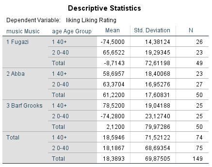

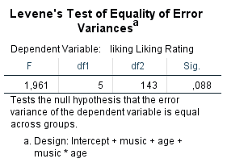

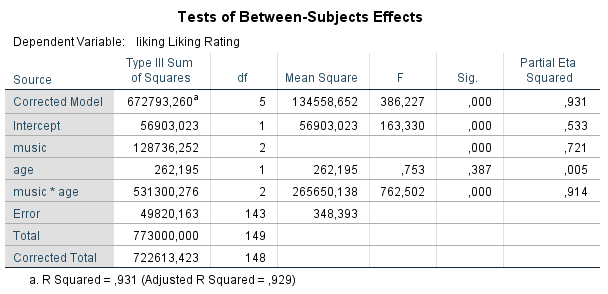

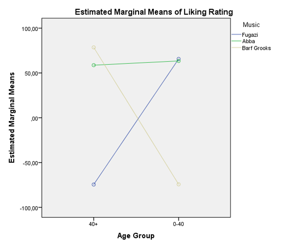

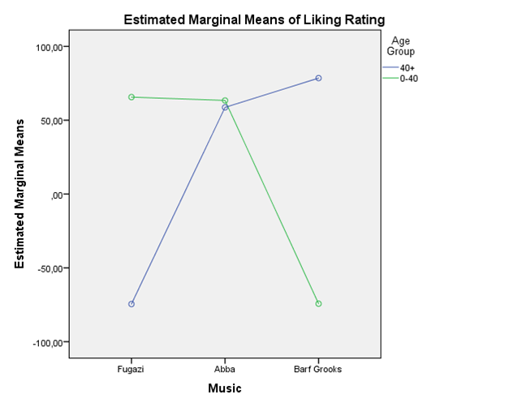

   De ‘variance ratio’ is een manier om de assumptie van de homogeniteit van varianties te onderzoeken. In dit onderzoek geldt 3 als grenswaarde voor hoeveel keer groter de grootste ‘within-group’ variantie mag zijn ten opzichte van de kleinste ‘within-group’ variantie.

   **Variance ratio = largest ‘within-group variance’/ smallest ‘within-group variance’**

   Is volgens de ‘variance ratio’ aan de assumptie van homogeniteit van varianties voldaan?
   1. **FALSE:** De variance ratio is ongeveer 2.6, kleiner dan 3, daarom kunnen we niet uitgaan van een gelijke ‘within-group’ variantie tussen de groepen
   2. **TRUE:** De variance ratio is ongeveer 2.6, kleiner dan 3, daarom kunnen we uitgaan van een gelijke ‘within-group’ variantie tussen de groepen
   3. **FALSE:** De variance ratio is ongeveer 1.6, kleiner dan 3, daarom kunnen we niet uitgaan van een gelijke ‘within-group’ variantie tussen de groepen
   4. **FALSE:** De variance ratio is ongeveer 1.6, kleiner dan 3, daarom kunnen we uitgaan van een gelijke ‘within-group’ variantie tussen de groepen
   1. False
   2. True
   3. False
   4. False